# Lista 1 Bioestat

# Question 1

Considere os dados apresentados no Anexo 1. Há interesse em saber qual é o de variação dos dados sob o tratamento $A$ e sob o tratamento $B$. Além disso, há interesse em estimar o valor da verdadeira média da resposta sob o tratamento $A$ (e sob o $B$).

Calcule os seguintes intervalos:
$$\begin{align*}
&\left(\bar{Y}_{j}-2 s_{j} ; \bar{Y}_{j}+2 s_{j}\right) ; \quad j=A, B
\end{align*}$$
Qual é a utilidade destes intervalos? Interprete-os. Faça suposições que achar necessárias.

```r
Anexo1 <- data.frame(Trat = c(rep("A", 10),rep("B", 10)),
                    Resp = c(89.7, 81.4, 84.5, 84.8, 87.3,
                             79.7, 85.1, 81.7, 83.7, 84.5,
                             84.7, 86.1, 83.2, 91.9, 86.3,
                             79.3, 82.6, 89.1, 83.7, 88.5))


#interval A
A <- Anexo1[Anexo1$Trat=="A",]$Resp

mean(A) - 2*sd(A)
```

```
[1] 78.4364
```

```r
mean(A) + 2*sd(A)
```

```
[1] 90.0436
```

```r
#interval B
B <- Anexo1[Anexo1$Trat=="B",]$Resp

mean(B) - 2*sd(B)
```

```
[1] 78.23935
```

```r
mean(B) + 2*sd(B)
```

```
[1] 92.84065
```

Os intervalos calculados para as médias dos tratamentos são:

- Tratamento $A$ $\to$ $[78.44, \; 90.04]$
- Tratamento $B$ $\to$ $[78.24, \; 92.84]$

Ao estimar a média em cima das nossas amostras (que notamos são bem pequenas), é mais interessante, e com menor erro, reportar um intervalo de possíveis médias do que um único valor. De forma análoga ao intervalo de confiança, nosso intervalo irá summarizar a variabilidade da nossa variável aleatória.

Esses intervalos nos informam conjuntos de valores que encontram-se a até dois desvios padrões da média amostral (tanto para baixo quanto para cima). Se os nossos dados fossem normais (é impossível aferir a normalidade pois o número de amostras é insuficiente), poderíamos supor que os valores abarcados por esses intervalos representam cerca de 95% da área abaixo da curva normal. Isso seria porque a média somada com duas vezes o desvio padrão é igual ao percentil 97,5 e a média subtraída de 2 vezes o desvio padrão é igual ao percentil 2,5. Assim, podemos dizer que a média mais ou menos dois desvios padrões é o intervalo que contém 95% dos dados da amostra. Logo, os intervalos estimariam quase toda a variação possível para as médias, o que é útil para apresentar a dispersão dos dados dos tratamentos.

# Question 2

Calcule os seguintes intervalos:
$$\begin{align*}
&\left(\bar{Y}_{j}-2 s_{j} / \sqrt{n_{j}} ; \bar{Y}_{j}+2 s_{j} / \sqrt{n_{j}}\right) ; \quad j=A, B\\
&\left(\bar{d}-2 s_{d} ; \bar{d}+2 s_{d}\right)
\end{align*}$$

Qual é a utilidade de cada um destes intervalos? Interprete-os. Faça suposições que achar necessárias. Com base neste intervalo decida se a média do tratamento B é maior que a de A.

```r
#interval A
mean(A) - 2*sd(A)/sqrt(length(A))
```

```
[1] 82.40474
```

```r
mean(A) + 2*sd(A)/sqrt(length(A))
```

```
[1] 86.07526
```

```r
#interval B
mean(B) - 2*sd(B)/sqrt(length(B))
```

```
[1] 83.23133
```

```r
mean(B) + 2*sd(B)/sqrt(length(B))
```

```
[1] 87.84867
```

```r
#interval difference
d_bar = mean(B) - mean(A)

d_bar - 2*sqrt((sd(A)^2 + sd(B)^2)/10)
```

```
[1] -1.64926
```

```r
d_bar + 2*sqrt((sd(A)^2 + sd(B)^2)/10)
```

```
[1] 4.24926
```

Nesse exercício, ao dividir o desvio padrão pela raiz do número de variáveis, temos então o erro padrão da média. O erro padrão é mais apropriado para se utilizar para os intervalos, pois ele mede a provável diferença da média estimada para a média populacional. O desvio padrão é apenas a dispersão dos dados em torno da média.

Intervalos de confiança são uteis para construirmos um conjunto de valores em que temos quase certeza que o valor real do estimador de interesse (média, mediana, diferença entre as médias etc) está contido nesse conjunto. O intervalo de confiança permite que observemos tanto o efeito do tamanho amostral como da incerteza associada a nossa estimativa, uma vez que ambos afetam o tamanho do intervalo.

Para o primeiro caso, assumindo que o tamanho amostral dos tratamentos A e B são representativos e que foram amostradas de forma aleatória e independente, podemos construir nossos intervalos de confiança. Vamos assumir também uma distribuição normal para esses dados. Usando um nível de confiança de cerca de 95% (dois desvios padrões em uma distribuição normal), observamos que o tamanho do intervalo de confiança para o tratamento A é menor do que o do tratamento B. Isso já é um indicativo de que o tratamento B tem valores com maior variação se comparado ao tratamento A. Além disso, o intervalo de confiança do tratamento A é menor, fazendo com que ele seja mais confiável. Logo, esses intervalos são úteis para saber o quão confiável é uma estimativa pontual (média amostral, por exemplo) com relação ao valor real dessa estimativa (média populacional, por exemplo), justamente por indicar um conjunto de valores em que o valor real pode estar contida.

Para o segundo caso, estamos calculando um intervalo para a diferença entre as médias ($\bar{d}$) dos tratamentos. Assumindo uma amostragem aleatória e independente, uma variância igual em ambas as populações e que essa população segue uma distribuição t (devido ao baixo $n$ amostral), podemos dizer se a diferença entre as médias de ambos os tratamentos é ou não significativa por meio de um intervalo de confiança. Como o intervalo calculado para a diferença entre as médias inclui o valor zero (nenhuma diferença entre as médias), podemos supor que a diferença entre essas médias não são estatisticamente diferentes, portanto não podemos supor que a média do tratamento $B$ é realmente maior do que a do tratamento $A$.

# Exercício 3

Seja $\mu_D = \mu_A - \mu_B$ verdadeira diferença entre as médias dos tratamentos $A$ e $B$. Vamos agora obter o intervalo de confiança bootstrap para $\mu_D$. Para isso, utilizando os recursos do aplicativo R, realize os seguintes passos:

Com base neste intervalo decida se a média do tratamento B é maior que a de A.

```r
#calculate
d <- mean(A) - mean(B)

s_d <- sqrt((var(A) + var(B))/10) #s_d

#Boostrap function
ex3 <- function(A, B) {
  resample_A <- sample(A, replace = TRUE)
  resample_B <- sample(B, replace = TRUE)

  d_b <- mean(resample_A) - mean(resample_B)

  s_d_b <- sqrt((var(resample_A) + var(resample_B))/10)

  t_b <- (d_b - d)/s_d_b

  return(t_b)
}

#repeat bootstrap 1000 times and get t_b distribution
set.seed(1)
t_b <- vector()
for (i in seq(1:1000)) {
  t_b <- append(t_b, ex3(A,B))
}

#Percentiles
percentis = quantile(t_b, c(.025, .975))

#Bootstrap confidence intervals
d + percentis[1]*s_d
```

```
     2.5%
-4.284031
```

```r
d + percentis[2]*s_d
```

```
   97.5%
1.896296
```

O intervalo de confiança bootstrap é: $[-4.28, \; 1.90)].$

Dado que esse intervalo inclui o valor zero (nulo), podemos supor que a diferença entre as médias não são estatisticamente significantes. Logo, temos que a média do tratamento B não é necessariamente maior do que a do tratamento A quando observamos o intervalo da diferença entre as médias calculado por meio de bootstrap.

#Exercício 4

Considere agora os dados apresentados no Anexo 2.

Há interesse em conhecer o verdadeiro valor da pulsação média ($\mu$) de estudantes em repouso. Com base nos dados do Anexo 2, construa um intervalo de confiança para $\mu$ com coeficiente de $95\%$ de confiança. Qual é o comprimento do intervalo? Qual é a margem de erro desse intervalo?

```r
dadosPulse <- read.csv2("Pulse.csv")

margem_erro = 1.96*sd(dadosPulse$P1)/sqrt(length(dadosPulse$P1))

CI_lower = mean(dadosPulse$P1) - margem_erro
CI_lower
```

```
[1] 70.62
```

```r
CI_upper = mean(dadosPulse$P1) + margem_erro
CI_upper
```

```
[1] 75.11913
```

```r
CI_upper - CI_lower
```

```
[1] 4.499128
```

```r
margem_erro
```

```
[1] 2.249564
```

Assumindo uma distribuição normal para os dados de pulso dos estudantes em repouso, podemos usar o valor de $1.96$ na tabela z que corresponde a área de $95\%$ abaixo da curva normal.

O intervalo calculado foi: $[70.62, \; 75.12]$, unidade em batimentos/min.

# Question 5

Suponha que 100 experimentos independentes sejam realizados e que o verdadeiro valor da pulsação média ($\mu$) de estudantes em repouso seja de $72$ batimentos/min. Usando o aplicativo R, explore os recursos da library e encontre intervalos de $95\%$ de confiança para $\mu$ em amostras de tamanho $92$. Em sua simulação, em quantos experimentos o intervalo obtido incluiu o verdadeiro valor de $\mu$? Em quantos experimentos é esperado que o intervalo inclua o verdadeiro valor de $\mu$?

Rodando vária vezes o seguinte comando:

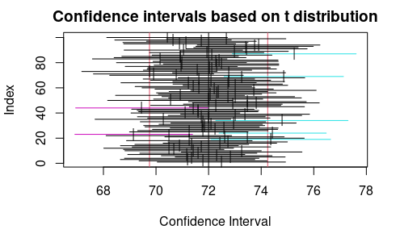

```r
library(RcmdrPlugin.TeachingDemos)
ci.examp(mean.sim = 72, sd = 11, n = 92, reps = 100, conf.level =
           0.95, method = "t")
```

# Exercício 6

Diferentes pesquisadores adotaram os seguintes modelos estatísticos na análise dos dados Pulse.
$$\begin{align*}
& M1: P2=\beta_{0}+\beta_{1} P1c + e ; \quad P1 c=P 1-média(P1)\\
& M2: P2=\beta_{0}+\beta_{1} Ran + e\\
& M3: P2=\beta_{0}+\beta_{1} P1c+\beta_{2} Ran + e\\
& M4: P2=\beta_{0}+\beta_{1} P1c+\beta_{2} Ran+\beta_{3}\left(P1c * Ran\right)+e
\end{align*}$$
Considerando premissas clássicas (erros independentes, normais, média $0$ e variância constante) e usando os recursos do aplicativo R, ajuste os modelos $M1$, $M2$, $M3$ e $M4$. Apresente razões que poderiam ter levado cada pesquisador a escolher tal modelagem dos dados. Interprete os coeficientes de regressão. Comente os resultados (valores dos resíduos; significância dos coeficientes; coeficiente de determinação ($R^2$); estatística F ($H_0: \beta’s=0 x H_1$: pelo menos um $\beta$ não nulo). Qual modelo você escolheria? Justifique. Nota: Veremos no curso, alternativas de ajuste dos modelos $M2$ e $M3$ via ANOVA e ANCOVA.

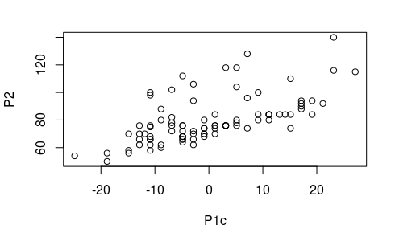

```r
P1 <- dadosPulse$P1
P2 <- dadosPulse$P2

#Ajuste do modelo M1
#y=b0+b1P1c+e
P1c<-P1-mean(P1)
plot(P2~P1c)
```

```r
m1 <- lm(P2~P1c,dadosPulse)
summary(m1)
```

```
Call:
lm(formula = P2 ~ P1c, data = dadosPulse)

Residuals:
    Min      1Q  Median      3Q     Max
-20.477  -8.434  -5.168   4.314  41.178

Coefficients:
            Estimate Std. Error t value Pr(>|t|)
(Intercept)  80.0000     1.4114  56.682  < 2e-16 ***
P1c           0.9568     0.1289   7.422 6.22e-11 ***
---
Signif. codes:  0 ‘***’ 0.001 ‘**’ 0.01 ‘*’ 0.05 ‘.’ 0.1 ‘ ’ 1

Residual standard error: 13.54 on 90 degrees of freedom
Multiple R-squared:  0.3797,    Adjusted R-squared:  0.3728
F-statistic: 55.09 on 1 and 90 DF,  p-value: 6.218e-11
```

```r
names(m1)
```

```
 [1] "coefficients"  "residuals"     "effects"       "rank"
 [5] "fitted.values" "assign"        "qr"            "df.residual"
 [9] "xlevels"       "call"          "terms"         "model"
```

```r
m1$coefficients
```

```
(Intercept)         P1c
 80.0000000   0.9567994
```

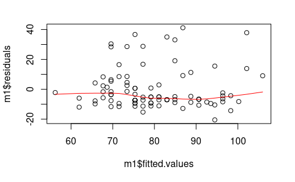

```r
plot(m1$fitted.values,m1$residuals)
lines(lowess(m1$fitted.values,m1$residuals),col="red")
```

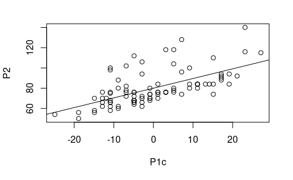

```r
plot(P2~P1c)
abline(m1)
```

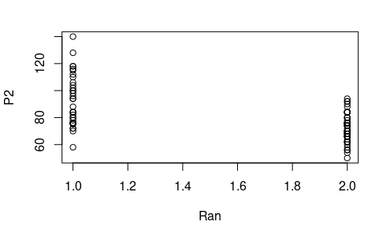

```r
#Ajuste do modelo M2
#y=b0+b2Ran+e
Ran <- dadosPulse$Ran

plot(P2~Ran)
```

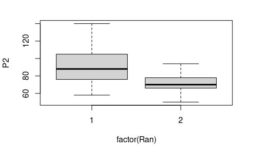

```r
plot(P2~factor(Ran))
```

```r
m2<-lm(P2~Ran)
summary(m2)
```

```
Call:
lm(formula = P2 ~ Ran)

Residuals:
    Min      1Q  Median      3Q     Max
-34.514 -10.316  -2.316   7.684  47.486

Coefficients:
            Estimate Std. Error t value Pr(>|t|)
(Intercept)  112.713      5.098  22.109  < 2e-16 ***
Ran          -20.198      3.015  -6.699 1.77e-09 ***
---
Signif. codes:  0 ‘***’ 0.001 ‘**’ 0.01 ‘*’ 0.05 ‘.’ 0.1 ‘ ’ 1

Residual standard error: 14.04 on 90 degrees of freedom
Multiple R-squared:  0.3327,    Adjusted R-squared:  0.3253
F-statistic: 44.88 on 1 and 90 DF,  p-value: 1.768e-09
```

```r
m2$coefficients #igual às médias dos grupos
```

```
(Intercept)         Ran
   112.7128    -20.1985
```

```r
mean(P2[Ran=="0"]) #intercept
```

```
[1] NaN
```

```r
mean(P2[Ran=="1"]) #intercept + Ran
```

```
[1] 92.51429
```

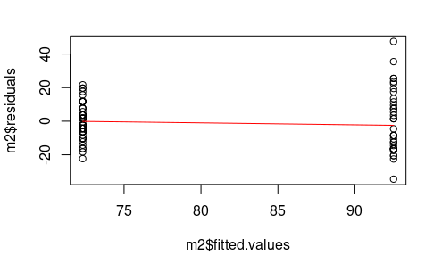

```r
plot(m2$fitted.values,m2$residuals)
lines(lowess(m2$fitted.values,m2$residuals),col="red")
```

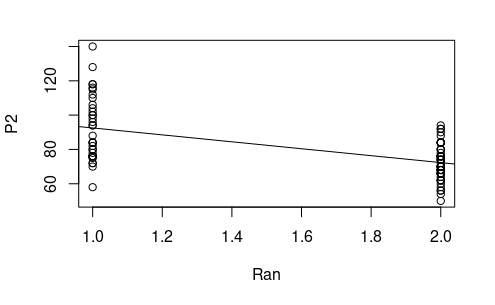

```r
plot(P2~Ran)
abline(m2)
```

```r
#Ajuste do modelo M3
#y=b0+b1P1c+b2Ran+e

library(car)

Ran <- recode(Ran,"1='1';2='0'")
Ran
```

```
 [1] 1 1 1 1 1 1 1 1 1 1 1 1 1 1 1 1 1 1 1 1 1 1 1 1 1 1 1 1 1 1 1 1 1
[34] 1 1 0 0 0 0 0 0 0 0 0 0 0 0 0 0 0 0 0 0 0 0 0 0 0 0 0 0 0 0 0 0 0
[67] 0 0 0 0 0 0 0 0 0 0 0 0 0 0 0 0 0 0 0 0 0 0 0 0 0 0
```

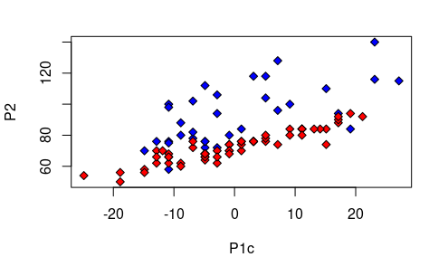

```r
plot(P2~P1c, pch=23, bg=c('red', 'blue')[factor(Ran)])
```

```r
m3<-lm(P2~P1c+Ran)
summary(m3)
```

```
Call:
lm(formula = P2 ~ P1c + Ran)

Residuals:
     Min       1Q   Median       3Q      Max
-25.3037  -3.9749  -0.2817   3.1931  29.6459

Coefficients:
            Estimate Std. Error t value Pr(>|t|)
(Intercept) 72.72504    1.30162  55.873  < 2e-16 ***
P1c          0.91247    0.09366   9.743 1.09e-15 ***
Ran         19.12274    2.11209   9.054 2.90e-14 ***
---
Signif. codes:  0 ‘***’ 0.001 ‘**’ 0.01 ‘*’ 0.05 ‘.’ 0.1 ‘ ’ 1

Residual standard error: 9.822 on 89 degrees of freedom
Multiple R-squared:  0.6771,    Adjusted R-squared:  0.6698
F-statistic: 93.31 on 2 and 89 DF,  p-value: < 2.2e-16
```

```r
m3$coefficients
```

```
(Intercept)         P1c         Ran
 72.7250440   0.9124706  19.1227414
```

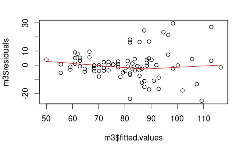

```r
plot(m3$fitted.values,m3$residuals)
lines(lowess(m3$fitted.values,m3$residuals),col="red")
```

```r
b0<-m3$coefficients[1]
b0
```

```
(Intercept)
   72.72504
```

```r
names(b0)<-NULL
b0
```

```
[1] 72.72504
```

```r
b1<-m3$coefficients[2]
names(b1)<-NULL
b2<-m3$coefficients[3]
names(b2)<-NULL

plot(P2~P1c, pch=23, bg=c('red', 'blue')[factor(Ran)])
abline(b0,b1, col="red")
```

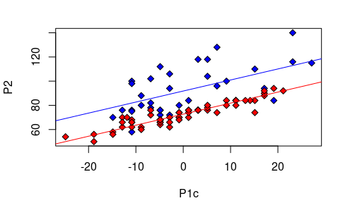

```r
abline((b0+b2),b1,col="blue")
```

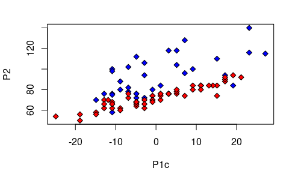

```r
#Ajuste do modelo M4
#y=b0+b1P1c+b2Ran+b3(P1c*Ran)+e
P1cRan<-P1c*Ran
plot(P2~P1c, pch=23, bg=c('red', 'blue')[factor(Ran)])
```

```r
m4<-lm(P2~P1c+Ran+P1cRan)
summary(m4)
```

```
Call:
lm(formula = P2 ~ P1c + Ran + P1cRan)

Residuals:
     Min       1Q   Median       3Q      Max
-27.0252  -4.0728  -0.5624   2.8070  29.0471

Coefficients:
            Estimate Std. Error t value Pr(>|t|)
(Intercept)  72.6966     1.3045  55.729  < 2e-16 ***
P1c           0.8490     0.1216   6.984 5.22e-10 ***
Ran          19.0829     2.1165   9.016 3.80e-14 ***
P1cRan        0.1570     0.1912   0.821    0.414
---
Signif. codes:  0 ‘***’ 0.001 ‘**’ 0.01 ‘*’ 0.05 ‘.’ 0.1 ‘ ’ 1

Residual standard error: 9.84 on 88 degrees of freedom
Multiple R-squared:  0.6796,    Adjusted R-squared:  0.6686
F-statistic: 62.21 on 3 and 88 DF,  p-value: < 2.2e-16
```

```r
m4$coefficients
```

```
(Intercept)         P1c         Ran      P1cRan
 72.6965672   0.8489790  19.0828811   0.1570483
```

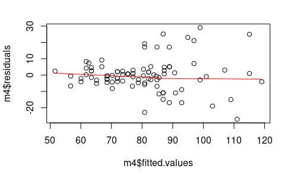

```r
plot(m4$fitted.values,m4$residuals)
lines(lowess(m4$fitted.values,m4$residuals),col="red")
```

```r
b0<-m4$coefficients[1]
b0
```

```
(Intercept)
   72.69657
```

```r
names(b0)<-NULL
b0
```

```
[1] 72.69657
```

```r
b1<-m4$coefficients[2]
names(b1)<-NULL
b2<-m4$coefficients[3]
names(b2)<-NULL
b3<-m4$coefficients[4]
names(b3)<-NULL
plot(P2~P1c, pch=23, bg=c('red', 'blue')[factor(Ran)])
abline(b0,b1, col="red")
```

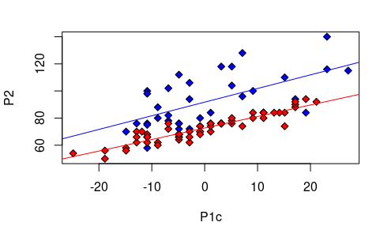

```r
abline((b0+b2),(b1+b3),col="blue")
```

### Modelo 1

Embora os parâmetros do modelo estejam bem ajustados, o coeficiente de regressão linear ($R^2$) é baixo ($0.3797$). Isso significa que cerca de $38\%$ da variação da variável resposta ($Y$) pode ser explicada por nossa variável explicativa ($P1c$), logo existem diferenças relevantes entre os valores observados ($Y$) e os usados para ajustar o modelo ($P1c$). Olhando para a dispersão dos resíduos, observamos um padrão aleatório, indicando que apesar do baixo valor do coeficiente de regressão, este modelo representa bem os dados. Por fim, temos que o nosso teste F apresenta um valor abaixo ($6.218 \cdot 10^{-11}$) do valor crítico, indicando que o nosso modelo ajustasse melhor aos nossos dados do que um modelo sem variáveis explicativas.

### Modelo 3

O modelo 3 é um modelo aditivo, levando em conta as variáveis explicativas presentes tanto no modelo 1 ($P1c$) quanto no modelo 2 ($Ran$). O caso em que tanto o $\beta_1$ e o $\beta_2$ assumem o valor zero, faz com que a variável resposta $Y$ assuma o valor do coeficiente linear $\beta_0$. O valor estimado para esse parâmetro foi de $72.72504$, sendo também estatisticamente significante ($2 \cdot 10^{-16}$) quando diante do valor crítico. Assumindo o caso em que o estudante não foi selecionado para correr na esteira ($Ran = 0$), o valor da variável resposta será a soma do coeficiente linear com o termo $\beta_1 \cdot P1c$,tendo sido o coeficiente $\beta_1$ estimado em $0.91247$ de acordo com os dados fornecidos ao nosso modelo.

O caso contrário é quando o estudante correu na esteira ($Ran = 1$), porém a sua medida de $P1$ é igual a média de $P1$ ($P1c = P1 – média (P1)$), zerando o termo $\beta_1*P1c$ e fazendo com que o valor da variável resposta seja a soma entre o coeficiente linear e o termo $\beta_2 \cdot Ran$, sendo que o coeficiente $\beta_2$ foi estimado com um valor de $19.12274$. Ambos os coeficientes $\beta_1$ e $\beta_2$ são estatisticamente significantes ($1.09\cdot 10^{-15}$ e $2.90 \cdot 10^{-14}$) diante do valor crítico estipulado para o teste t.

Dito isso, temos nesse caso que conseguimos traçar duas retas para explicarem os nossos dados. Uma reta que adequasse bem ao grupo de estudantes que não correram (reta vermelha) assim como aqueles que correram (reta azul).

Esse modelo apresenta $R^2 = 0.6771$. Isso significa podemos explicar cerca de $68\%$ da variação da variável resposta ($Y$) pelas variáveis explicativas $P1c$ e $Ran$. Além disso, olhando para a dispersão dos resíduos, elas parecem seguir um padrão aleatório que indica que nosso modelo não possui nenhum viés que possa estar interferindo na predição da variável resposta ($Y$). Por fim, a estatística F apresenta um p-valor de $2.2 \cdot 10^{-16}$, sendo abaixo do valor crítico, podemos rejeitar a hipótese nula de que um modelo sem variáveis explicativas é mais adequado aos dados.

### Modelo 4

Esse modelo é do tipo integrativo. Temos duas variáveis explicativas ($P1c$ e $Ran$) e a interação entre essas duas variáveis ($P1c \cdot Ran$) formando a terceira variável explicativa. O caso em que todos os termos são nulos faz com que a variável resposta ($Y$) assuma o valor estimado do coeficiente linear ($\beta_0 = 72.6966$), tendo esse significância estatística ($2 \cdot 10^{-16}$) diante do p-crítico de $5\%$ do teste t. Para os casos das variáveis explicativas $P1c$ e $Ran$, este modelo comporta-se como o modelo 3, porém com diferenças nos valores estimados dos coeficientes que acompanham essa variáveis ($\beta_1 = 0.8490$ e $\beta_2 = 19.0829$). Ambos os coeficientes são estatisticamente significantes. O caso da terceira variável explicativa ($P1c \cdot Ran$) é interessante, pois o valor estimado de seu coeficiente ($\beta_3 = 0.1570$) não é estatisticamente significante ($p-valor = 0.414$) para o nosso modelo. Isso significa que esta variável explicativa não agrega informação ao nosso modelo, portanto, sendo dispensável para a predição do valor observado. O coeficiente de regressão linear ($R^2$) deste modelo não aumenta muito se comparado ao do modelo anterior. O valor encontrado de $0.6796$ para o coeficiente de regressão linear indica que cerca de $68\%$ do erro da variável resposta ($Y$) pode ser explicada pelas variáveis explicativas. Além disso, observando os comportamentos dos resíduos, é possível traçar uma distribuição aleatória. Permitindo a inferência de que não existem vieses aparentes em nosso modelo. Por fim, o valor da estatística F ($2.2 \cdot 10^{-16}$) fica abaixo do p-crítico de $5\%$, permitindo que rejeitemos a hipótese nula de que um modelo sem variáveis explicativas seria mais adequado aos dados.

### Comparando os modelos

O modelo mais adequado seria o modelo 3. Tanto o modelo 1 quanto 2 apresentam limitações, uma vez que consideram apenas uma variável explicativa, fazendo com que eles não sejam capazes de explicar bem o erro apresentado pela variável resposta ($Y$). Isso pode ser observado de acordo com os baixos valores do coeficiente de regressão linear para ambos os modelos. A combinação desses dois modelos no modelo 3 (modelo aditivo) melhora bastante o coeficiente de regressão linear, assim como podemos observar um padrão aleatório na distribuição dos resíduos, demonstrando que aparentemente não existem vieses sobre o nosso modelo. Além disso, podemos observar que esse modelo adequasse bem a situação de corrida ($Ran=1$) qual os estudantes foram expostos. Por fim, apesar do modelo 4 apresentar um pequeno ganho com relação ao coeficiente de regressão linear a despeito do modelo 3, observamos que a variável explicativa $P1c \cdot Ran$ não agrega informação a modelagem. Isso pode ser observado pelo alto valor-p que o coeficiente $\beta_3$ apresentou para sua estimativa, superando o p-crítico e fornecendo evidências para que possamos descartar este termo de nosso modelo.